# Multi-Variate-regression

Sandeep Anand

April 15, 2017

## Calling ‘lm’

- Fitting all the variables

```r
summary(lm(Fertility~., data=swiss))$coef
```

```
##                    Estimate  Std. Error   t value     Pr(>|t|)
## (Intercept)      66.9151817 10.70603759  6.250229 1.906051e-07
## Agriculture      -0.1721140  0.07030392 -2.448142 1.872715e-02
## Examination      -0.2580082  0.25387820 -1.016268 3.154617e-01
## Education        -0.8709401  0.18302860 -4.758492 2.430605e-05
## Catholic          0.1041153  0.03525785  2.952969 5.190079e-03
## Infant.Mortality  1.0770481  0.38171965  2.821568 7.335715e-03
```

- The -0.17 , means that there is an expected decrease of 0.17 in fertility for men , for every 1% increase in percentage of males involved in Agriculture , and this is the case with other variables remaining constant
- Just to consider that the these are actually percentages
- R actually gives us the t-value for a t-test of H0: Beta(agri) = 0

```r
spray2<-relevel(InsectSprays$spray, "C")
summary(lm(count~spray2,data=InsectSprays))$coef
```

```
##              Estimate Std. Error  t value     Pr(>|t|)
## (Intercept)  2.083333   1.132156 1.840148 7.024334e-02
## spray2A     12.416667   1.601110 7.755038 7.266893e-11
## spray2B     13.250000   1.601110 8.275511 8.509776e-12
## spray2D      2.833333   1.601110 1.769606 8.141205e-02
## spray2E      1.416667   1.601110 0.884803 3.794750e-01
## spray2F     14.583333   1.601110 9.108266 2.794343e-13
```

—Ancova * Analysis of Covariance * Fitting a number of lines with different intercepts * If you multiply you will get an interaction

```r
library(datasets);data(swiss);library(ggplot2)
head(swiss)
```

```
##              Fertility Agriculture Examination Education Catholic
## Courtelary        80.2        17.0          15        12     9.96
## Delemont          83.1        45.1           6         9    84.84
## Franches-Mnt      92.5        39.7           5         5    93.40
## Moutier           85.8        36.5          12         7    33.77
## Neuveville        76.9        43.5          17        15     5.16
## Porrentruy        76.1        35.3           9         7    90.57
##              Infant.Mortality
## Courtelary               22.2
## Delemont                 22.2
## Franches-Mnt             20.2
## Moutier                  20.3
## Neuveville               20.6
## Porrentruy               26.6
```

```r
# Create a binary  catholic variable, 1 if the county is majority catholic and majority protestant
library(dplyr)
```

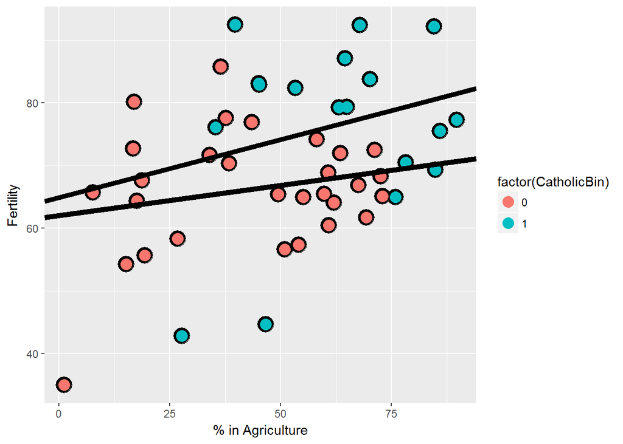

```r
swiss = mutate(swiss, CatholicBin=1*(Catholic>50))

#fit4<- lm(Fertility~Agriculture, data=swiss)

#fit5<-lm(Fertility~Agriculture+factor(CatholicBin), data=swiss)

fit6<-lm(Fertility~Agriculture*factor(CatholicBin), data=swiss)

g<-ggplot(swiss, aes(x=Agriculture, y=Fertility, colour=factor(CatholicBin)))
g=g+geom_point(size=6, colour="black")+geom_point(size=4)
g=g+xlab("% in Agriculture") + ylab("Fertility")

g3<-g
g3<-g3+geom_abline(intercept = coef(fit6)[1], slope=coef(fit6)[2], size=2)
g3<-g3+geom_abline(intercept = coef(fit6)[1]+coef(fit6)[3], slope=coef(fit6)[2]+coef(fit6)[4], size=2)
g3
```

### Analysis of residuals,Residual vs Fit

- To understand these plots , we would need to know Influential, high leverage and outlying points
- A data point that is very far from the middle of the axis or the Average will have high leverage/influence , basically the averages of (x,y) can be said as the fulcrum and the farther you are away from the fulcrum it will be more influential and the nearer you are , you are less influential
- Influence is the conditon wether a point which has a higher leverage , but weather the point opts to exert that leverage is the important part,
- The point will not have a large dfbeta value , but it will have a large leverage value
- **Outliers** - It could be due to spurious or due to real processes
- Influence can be checked best , by keeping the point and check what are the values you are estimating and then take out the point and see how the estimates are changing
- Check ?influence.measures , for most of the outlier analysis and the functions you will need to do analysis
- press residuals = resid(fit)/(1-hatvalues(fit))
- A fitted model having been produced, each observation in turn is removed and the model is refitted using the remaining observations. The out-of-sample predicted value is calculated for the omitted observation in each case, and the PRESS statistic is calculated as the sum of the squares of all the resulting prediction errors
- equation block:
  $$PRESS=\sum_{i=1}^{n} (y_i-\hat{y_i})^{2}$$
- Given this procedure, the PRESS statistic can be calculated for a number of candidate model structures for the same dataset, with the lowest values of PRESS indicating the best structures. Models that are over-parameterised (over-fitted) would tend to give small residuals for observations included in the model-fitting but large residuals for observations that are excluded.
- Plotting
- The Main plot that everyone does is to plot the residuals vs Fitted values
- Q-Q plot generally checks normality
- Standarized plots , plotting residuals at a different scale level
- Residuals vs Leverage, looks at any systematic pattern
- The hatvalues always lie between [0,1]
- Residual plots are very important as they zoom in very finely to the aspects of poor model fit

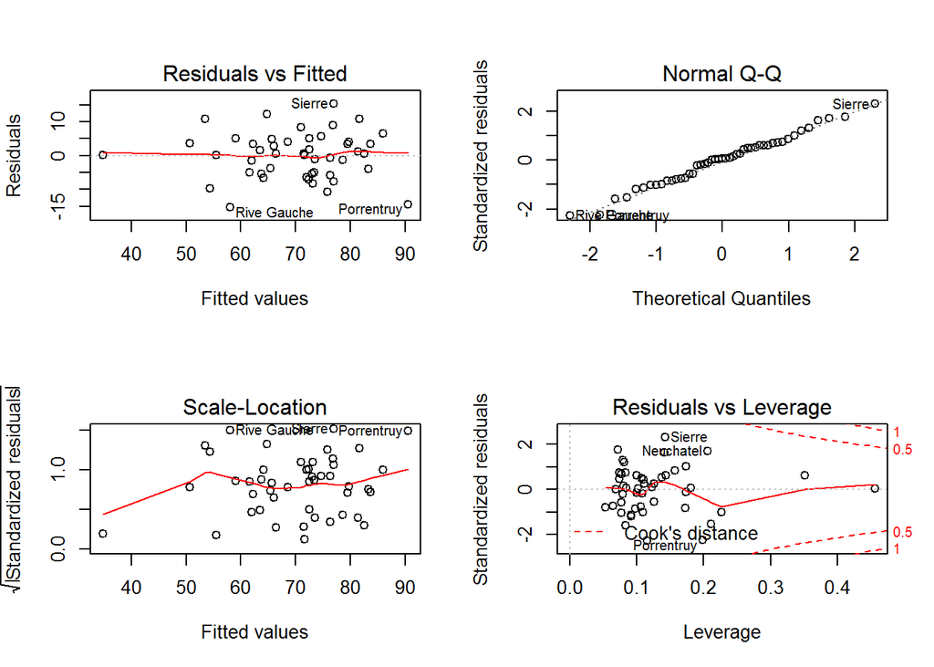

```r
data(swiss);library(ggplot2);par(mfrow=c(2,2))
fit7<-lm(Fertility~., data = swiss); plot(fit7)
```

## Residual Variation

- If we overfit or correctly fit the model, including all the necessary covariates and/or unnecessary covariates , the variance estimate is unbiased
- However , the variance of the variance is higher if we start to include unnecessary variables
- If we have a lot of regressors there are particular techniques such as PCA and factor analytic models on covariates , that are often useful to reduce the number of complex covariate spaces
- Good design and keeping the model covariates as random as possible , will actually lead to have a better model where we do not need all these complex analysis
- A good automated regression model, is nested likelihood ratio
- Given a coefficient that I’m interested in, I like to use covariate adjustment and multiple models to probe that effect to evaluate it for robustness and to see what other covariates knock it out. This isn’t a terribly systematic approach, but it tends to teach you a lot about the the data as you get your hands dirty.

## How to do nested model testing in R

```r
fit1 <- lm(Fertility ~ Agriculture, data = swiss)
fit3 <- update(fit8, Fertility ~ Agriculture + Examination + Education)
fit5 <- update(fit8, Fertility ~ Agriculture + Examination + Education + Catholic + Infant.Mortality)
anova(fit1, fit3, fit5)
```

```
## Analysis of Variance Table
##
## Model 1: Fertility ~ Agriculture
## Model 2: Fertility ~ Agriculture + Examination + Education
## Model 3: Fertility ~ Agriculture + Examination + Education + Catholic +
##     Infant.Mortality
##   Res.Df    RSS Df Sum of Sq      F    Pr(>F)
## 1     45 6283.1
## 2     43 3180.9  2    3102.2 30.211 8.638e-09 ***
## 3     41 2105.0  2    1075.9 10.477 0.0002111 ***
## ---
## Signif. codes:  0 '***' 0.001 '**' 0.01 '*' 0.05 '.' 0.1 ' ' 1
```